# Medias de tendencia central

Estrada Quezada Jocelyn Anahi

2/3/2022

### 1. ¿Qué son las medidas de tendencia central?

Son parametros estadisticos que informan sobre el centro de la distribucion de la muestra o poblacion estadistica.

#### Fuente: [medidas de tendencia](https://economipedia.com/definiciones/medidas-de-tendencia-central.html)

Para este ejemplo, primero generaremos una serie de **100** números aleatorios entre **1** y **20** mediante la función `sample`. El argumento `TRUE` nos permitirá generar una muestra con remplazo:

```r
numeros <- sample(1:20, 100, TRUE)
numeros
```

```
##   [1]  9 14 20  4  5 12 11  9 12  5  4  4 17 17 10 13 18 17  2  3 13 12  9 16 11
##  [26] 17  2  2  6 14 13 12 18  1  3 19 11  8  1 15  5  9  7  5 10  2  9  6 14  2
##  [51] 20 14  3  7 14 15  1 20 17  3 14  3 11  5 16  7  7 13 10 13 16 19 17  6  3
##  [76] 14 16 11  1 18 20  1  8  1  8 15  4  5 18  4 10  9  6 13 12  8 16 19  4 13
```

#### **2.- MEDIANA**

**Fuente: [Mediana](https://economipedia.com/definiciones/medidas-de-tendencia-central.html)** Para obtener la **mediana**, podemos ordenar los numeros de menor a mayor, **el número que esté en medio de la muestra será la mediana.** Si utilizamos R, se puede hacer el cálculo de la mediana con la función median:

```r
mediana <- median(numeros)
mediana
```

```
## [1] 10
```

#### 3. MEDIA.

Es el valor promedio de un conjunto de datos numericos, calculada como una suma del conjunto de valores dividida entre el numero total de valores.

#### Fuente: [Media](https://economipedia.com/definiciones/medidas-de-tendencia-central.html)

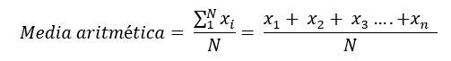

Formula Media Aritmetica

Si usamos R, podemos obtener la media de una muestra si utlilizamos la función **mean**:

```r
media <- mean(numeros)
media
```

```
## [1] 10.06
```

**4.- MODA** Es el valor que más se repite en una muestra estadística o población. No tiene fórmula en sí mismo. Lo que habría que realizar es la suma de las repeticiones de cada valor. **Fuente:[Moda](https://economipedia.com/definiciones/medidas-de-tendencia-central.html)**

Podemos saber cuál es la **frecuencia** (número de veces que aparece un elemento en una muestra) de cada número si dibujamos un **histograma** con la función hist, **aquel elemento con mayor frecuencia será la moda:**

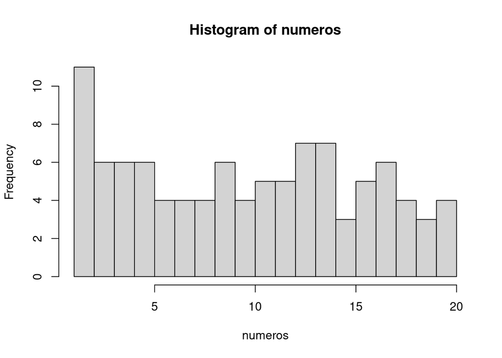

```r
# El argumento breaks nos permite dividir en histograma en las partes que queramos
hist(numeros, breaks = 20)
```

Para obtener un resultado con más precisión, podemos obtener la **moda** si generamos una **tabla de frecuencias** con la función *table* y la función `*data.frame*`, **aquel elemento con mayor frecuencia será la moda:**

```r
tabla.frecuencias <- data.frame(table(numeros))
tabla.frecuencias
```

```
##    numeros Freq
## 1        1    6
## 2        2    5
## 3        3    6
## 4        4    6
## 5        5    6
## 6        6    4
## 7        7    4
## 8        8    4
## 9        9    6
## 10      10    4
## 11      11    5
## 12      12    5
## 13      13    7
## 14      14    7
## 15      15    3
## 16      16    5
## 17      17    6
## 18      18    4
## 19      19    3
## 20      20    4
```

**5.- EJERCICIOS**

```r
# Con la función seq, creamos una secuencia de 1 a 10 en intervalos de 0.1 en 0.1
secuencia <- seq(1, 10, 0.1)
muestra <- sample(secuencia, 100, TRUE)
muestra
```

```
##   [1] 2.8 9.7 2.5 2.7 1.7 6.4 2.2 8.7 1.6 7.1 4.2 9.3 4.8 6.9 6.3 1.7 8.1 9.9
##  [19] 8.1 1.0 8.1 9.4 7.5 5.6 3.5 5.3 7.4 9.8 4.4 6.0 1.5 9.2 1.5 5.6 2.2 8.7
##  [37] 3.0 4.6 5.6 5.2 4.1 4.3 5.3 6.6 3.9 6.8 9.0 6.2 7.9 6.6 7.0 2.1 8.1 2.6
##  [55] 8.4 5.8 8.0 4.0 9.1 5.2 9.4 1.5 6.0 4.7 1.3 6.3 7.4 8.8 4.6 3.4 1.9 2.9
##  [73] 9.4 9.6 5.7 7.3 8.4 1.3 6.6 9.8 2.0 6.6 4.9 9.5 3.9 1.0 7.6 3.1 9.9 9.2
##  [91] 3.7 1.6 1.0 5.2 8.4 6.0 4.1 8.3 8.5 7.5
```

- MEDIANA

  ```r
  mediana <- median(1, 10, 0.1)
  mediana
  ```

  ```
  ## [1] 1
  ```

- **MEDIA**

```r
media <- mean(1, 10, 0.1)
media
```

```
## [1] 1
```

- **MODA**

[figure not shown]

```r
hist(1, 10, 0.1 , breaks = 100)
```

```r
tabla.frecuencias <- data.frame(table(1, 10, 0.1))
tabla.frecuencias
```

```
##   Var1 Var2 Var3 Freq
## 1    1   10  0.1    1
```